# HCP-D: Cognitive Control Behavior in Adolescence and the Role of Reward

- Show All Code
- Hide All Code
- View Source

Poster (pdf)

Email Me

```r
combine_kfold <- function(klist){
  #klist = lapply(models, \(x) x$criteria$kfold)
  lapply(klist, \(x) x$estimate['elpd_kfold', 'Estimate'])

  kfold_elpd_composite <- kfold1$estimates["elpd_kfold","Estimate"] + kfold2$estimates["elpd_kfold","Estimate"]
  kfold_elpd_se_composite <- sqrt(kfold1$estimates["elpd_kfold","SE"]^2+kfold2$estimates["elpd_kfold","SE"]^2)

}

read_fit_models <- function(model_name, model_dir = 'fits'){
  require(brms)
  fnames <- file.path(model_dir, sprintf('%s_c%02d.rds', model_name, 1:4))
  fnames <- fnames[unlist(lapply(fnames, file.exists))]
  models <- lapply(fnames, readRDS)
  fit <- combine_models(mlist = models)
  models[[1]][['criteria']]$kfold

  return(fit)
}

plot_cond_eff <- function(fit, xvar, xname, yname, conditions = NULL, condition_title = NULL, ribbon_color = '#bc5090', line_color = '#003f5c', mean_center_y = FALSE, method = 'posterior_epred', points = FALSE, points_size = .5, points_alpha = .5, hex = FALSE, hex_args = list(alpha = .8, binwidth = c(.5, .025)), hex_log = FALSE, breaks = NULL, labels = NULL) {
  require(brms)
  require(ggplot2)
  require(viridisLite)
  require(data.table)
  require(ggnewscale)
  epred <- conditional_effects(fit, effects = xvar,
                               conditions = conditions,
                               re_formula = NA,
                               prob = .95, robust = TRUE,
                               method = method, plot = FALSE)
  epred[[xvar]] <- as.data.table(epred[[xvar]])
  if(points){
    resp_var <- all.vars(fit$formula$formula)[[1]]
    points_geom <- geom_point(data = fit$data, aes_string(y = resp_var),
                              size = points_size, alpha = points_alpha)
  } else {
    points_geom <- NULL
  }
  if(hex){
    resp_var <- all.vars(fit$formula$formula)[[1]]
    mapping <- aes_string(y = resp_var)
    if(hex_log){
      hex_fill_scale <- scale_fill_viridis_c(option = 'mako', trans = 'log', begin = .4, end = .95)
    } else {
      hex_fill_scale <- scale_fill_viridis_c(option = 'mako', begin = .4, end = .95)
    }
    hex_geom <- do.call(geom_hex, c(list(data = fit$data, mapping = mapping), hex_args))
  } else {
    hex_geom <- NULL
    hex_fill_scale <- NULL
  }
  if(!is.null(conditions)){
    if(mean_center_y){
      cols <- c('estimate__', 'lower__', 'upper__')
      epred[[xvar]][, mean_estimate__ := mean(estimate__), by = xvar]
      epred[[xvar]][, (cols) := lapply(.SD, \(x) x - mean_estimate__), by = xvar, .SDcols = cols]
    }
    condition_name <- names(conditions)[1]
    set(epred[[xvar]], j = condition_name, value = factor(epred[[xvar]][[condition_name]], levels = conditions[,1]))
    if(!is.null(breaks)){
      scale_color <- scale_color_viridis_d(option = 'inferno', begin = 0, end = .6,
                                      breaks = breaks,
                                      labels = labels)
      scale_fill <- scale_fill_viridis_d(option = 'inferno', begin = .3, end = 1,
                             breaks = breaks,
                             labels = labels)
    } else {
      scale_color <- scale_color_viridis_d(option = 'inferno', begin = 0, end = .6)
      scale_fill <- scale_fill_viridis_d(option = 'inferno', begin = .3, end = 1)
    }
    p <- ggplot(epred[[xvar]], aes_string(x = xvar, y = 'estimate__')) +
      points_geom +
      hex_geom +
      hex_fill_scale +
      ggnewscale::new_scale_fill() +
      geom_ribbon(aes_string(ymin = 'lower__', ymax = 'upper__', fill = condition_name, group = condition_name),
                  alpha = .5) +
      geom_line(aes_string(color = condition_name, fill = NULL, group = condition_name)) +
      scale_color +
      scale_fill +
      labs(x = xname, y = yname, color = condition_title, fill = condition_title)
  } else {
    p <- ggplot(epred[[xvar]], aes_string(x = xvar, y = 'estimate__')) +
      points_geom +
      hex_geom +
      geom_ribbon(aes(ymin = lower__, ymax = upper__), fill = ribbon_color, alpha = .5) +
      geom_line(color = line_color) +
      new_scale_fill() +
      hex_fill_scale +
      labs(x = xname, y = yname)
  }
  p <- p +
    theme_minimal()
  return(p)
}

posterior_effect_size <- function(fit, newdata, es_name = 'Effect size'){
  y_pred <- posterior_epred(fit, newdata = newdata, re_formula = NA)
  ES_post <- data.frame(ES = y_pred[, 2] - y_pred[, 1])
  names(ES_post) <- es_name
  ES_summary <- posterior_summary(ES_post)
  return(list(summary = ES_summary, posterior = ES_post))
}

make_custom_prediction <- function(newdata, varnames = NULL){
  custom_prediction <- function(x, ...){
    pred_draws <- brms::posterior_epred(x, newdata, re_formula = NA)
    pred_draws_df <- posterior::as_draws_df(pred_draws)
    iter_per_chain <- brms::ndraws(x) / brms::nchains(x)
    pred_draws_df$.chain <- (pred_draws_df$.draw - 1) %/% iter_per_chain + 1
    pred_draws_df$.iteration <- (pred_draws_df$.draw - 1) %% iter_per_chain + 1
    if(is.null(varnames)){
      varnames <- 1:nrow(newdata)
    }
    names(pred_draws_df)[1:nrow(newdata)] <- varnames
    return(pred_draws_df)
  }
  return(custom_prediction)
}

remove_pss_draws <- function(psseq, keep){
  #psseq <- x_psseq
  #keep = x_prednames
  draws_cols <- c('.chain', '.iteration', '.draw')
  keep_ <- c(keep, draws_cols)
  psseq$base_draws <- psseq$base_draws[, keep_]
  for(i in seq_along(psseq$prior_scaled$draws_sequence)){
    psseq$prior_scaled$draws_sequence[[i]]$draws <- psseq$prior_scaled$draws_sequence[[i]]$draws[, keep_]
  }
  for(i in seq_along(psseq$likelihood_scaled$draws_sequence)){
    psseq$likelihood_scaled$draws_sequence[[i]]$draws <- psseq$likelihood_scaled$draws_sequence[[i]]$draws[, keep_]
  }
  gc()
  return(psseq)
}
powerscale_sequence_pred <- function(x, x_var, res = 20){
  require(data.table)
  #x is a brms fit
  #x <- rtageprepotalt_null_fit
  #x_var = 'age'
  #res = 20
  draws_cols <- c('.chain', '.iteration', '.draw')
  x_var_seq <- do.call(seq, c(as.list(range(x$data[, x_var])), length.out = 20))
  x_var_newdata <- data.frame(x_var = x_var_seq)
  formula_vars <- all.vars(x$formula$formula)
  response_var <- formula_vars[attr(terms(x$formula$formula), "response")]
  covars <- x$data[1, formula_vars[which(!formula_vars %in% c(x_var, response_var))]]
  names(x_var_newdata) <- x_var
  x_var_newdata <- cbind(x_var_newdata, covars)
  x_prednames <- paste('newdata', 1:nrow(x_var_newdata), sep = '_')
  x_psseq <-
    remove_pss_draws(
      priorsense::powerscale_sequence(
        x,
        prediction = make_custom_prediction(x_var_newdata, varnames = x_prednames)),
      keep = x_prednames)

  prior_lik_scaled <- c(list(list(draws = x_psseq$base_draws)),
                        x_psseq[['prior_scaled']][['draws_sequence']],
                        x_psseq[['likelihood_scaled']][['draws_sequence']])

  powerscale_pred_draws_list <- lapply(prior_lik_scaled, \(y){
    d <- cbind(posterior_summary(as.data.frame(y$draws)[, x_prednames]), x_var_newdata)
    d$component <- y$powerscaling$component
    d$alpha <- y$powerscaling$alpha
    return(d)
  })
  powerscale_pred_draws <- rbindlist(powerscale_pred_draws_list, fill = TRUE)
  powerscale_pred_draws_base <- powerscale_pred_draws[is.na(alpha)]
  powerscale_pred_draws_ps <- powerscale_pred_draws[!is.na(alpha)]
  powerscale_pred_draws_base[, .id := 1:.N]
  powerscale_pred_draws_base <- powerscale_pred_draws_base[rep(.id, 2)]
  powerscale_pred_draws_base[, c('component', 'alpha', '.id') :=
                               list(rep(c('prior', 'likelihood'), each = .N/2),
                                    rep(1, .N),
                                    NULL)]
  powerscale_pred_draws <- rbindlist(list(powerscale_pred_draws_base, powerscale_pred_draws_ps))
  powerscale_pred_draws[, alpha_label := sprintf('%0.2f', alpha)]
  powerscale_pred_draws_plot <- ggplot(powerscale_pred_draws, aes(x = age, y = Estimate)) +
    geom_ribbon(aes(ymin = Q2.5, ymax = Q97.5), color = 'blue', fill = '#FAFAFA', alpha = .5) +
    geom_line(alpha = .5, color = 'red') +
    facet_grid(component ~ alpha_label, labeller = ) +
    theme_minimal()

  pred_psseq <- list(plot = powerscale_pred_draws_plot, plot_data = powerscale_pred_draws, psseq = x_psseq)
  return(pred_psseq)
}
```

# How does accuracy vary across age and prepotency?

**Plot age effect**

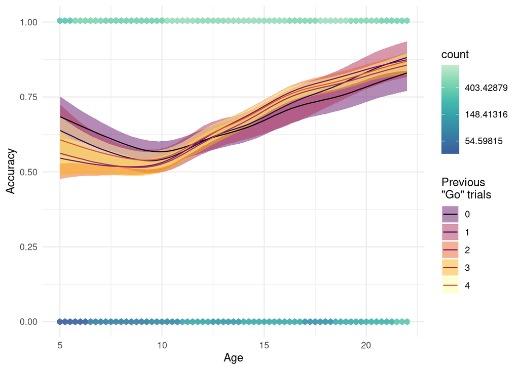

```r
acc_age_prepotofac_fit <- read_fit_models('acc_age_prepotofac')

print(plot_cond_eff(fit = acc_age_prepotofac_fit, xvar = 'age', xname = 'Age', yname = 'Accuracy',
                    conditions = data.frame(exact_prepotency_ofactor = 0:4),
                    condition_title = 'Previous\n"Go" trials', mean_center_y = FALSE,
                    method = 'posterior_epred', hex = TRUE, hex_log = TRUE,
                    hex_args = list(alpha = .9, binwidth = c(.25, .02))))
```

```r
#ggsave(filename = 'acc_age_prepotofac_fit.png', width = 11, height = 6.95, units = 'in', dpi = 300)
```

**Posterior predictive check**

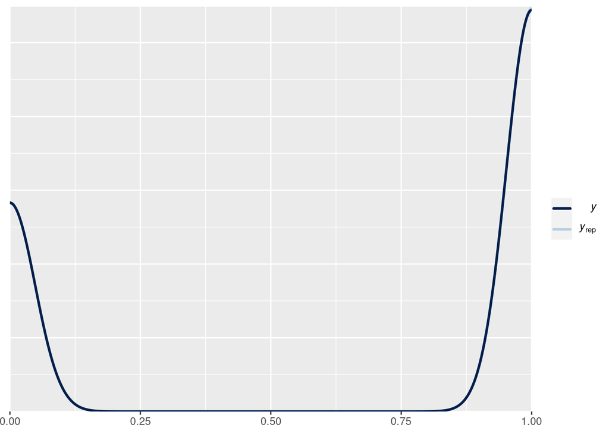

```r
pp_check(acc_age_prepotofac_fit)
```

**Model summary**

```r
summary(acc_age_prepotofac_fit)
```

```
 Family: bernoulli
  Links: mu = logit
Formula: correct ~ s(age, k = 10) + time + exact_prepotency_ofactor + s(age, by = exact_prepotency_ofactor, k = 10) + (1 + time | sID_factor:runN_factor) + (1 + time + exact_prepotency_ofactor | sID_factor)
   Data: structure(list(corrRespTrialType = structure(c(2L, (Number of observations: 54486)
  Draws: 4 chains, each with iter = 2500; warmup = 1500; thin = 1;
         total post-warmup draws = 4000

Smooth Terms:
                                     Estimate Est.Error l-95% CI u-95% CI Rhat
sds(sage_1)                              1.35      0.63     0.52     2.94 1.00
sds(sageexact_prepotency_ofactor1_1)     0.77      0.81     0.02     2.89 1.00
sds(sageexact_prepotency_ofactor2_1)     0.55      0.38     0.04     1.49 1.00
sds(sageexact_prepotency_ofactor3_1)     0.53      0.37     0.03     1.37 1.01
sds(sageexact_prepotency_ofactor4_1)     0.49      0.42     0.02     1.54 1.01
                                     Bulk_ESS Tail_ESS
sds(sage_1)                              1489     2001
sds(sageexact_prepotency_ofactor1_1)     1468     2549
sds(sageexact_prepotency_ofactor2_1)     1326     1592
sds(sageexact_prepotency_ofactor3_1)     1153     1528
sds(sageexact_prepotency_ofactor4_1)     1232     1624

Group-Level Effects:
~sID_factor (Number of levels: 1234)
                                                           Estimate Est.Error
sd(Intercept)                                                  0.66      0.02
sd(time)                                                       0.07      0.03
sd(exact_prepotency_ofactor.L)                                 0.55      0.06
sd(exact_prepotency_ofactor.Q)                                 0.39      0.05
sd(exact_prepotency_ofactor.C)                                 0.35      0.09
sd(exact_prepotency_ofactorE4)                                 0.28      0.07
cor(Intercept,time)                                            0.38      0.25
cor(Intercept,exact_prepotency_ofactor.L)                     -0.17      0.09
cor(time,exact_prepotency_ofactor.L)                           0.31      0.28
cor(Intercept,exact_prepotency_ofactor.Q)                      0.18      0.11
cor(time,exact_prepotency_ofactor.Q)                          -0.27      0.28
cor(exact_prepotency_ofactor.L,exact_prepotency_ofactor.Q)    -0.81      0.10
cor(Intercept,exact_prepotency_ofactor.C)                     -0.03      0.14
cor(time,exact_prepotency_ofactor.C)                           0.16      0.31
cor(exact_prepotency_ofactor.L,exact_prepotency_ofactor.C)     0.35      0.19
cor(exact_prepotency_ofactor.Q,exact_prepotency_ofactor.C)    -0.61      0.17
```

[output cut: 92 more lines]

```
Intercept                            2478     2693
time                                 8895     2821
exact_prepotency_ofactor.L           4324     3072
exact_prepotency_ofactor.Q           3242     3262
exact_prepotency_ofactor.C           4001     3282
exact_prepotency_ofactorE4           3936     3212
sage_1                               5869     2957
sage:exact_prepotency_ofactor1_1     4874     2518
sage:exact_prepotency_ofactor2_1     2448     2903
sage:exact_prepotency_ofactor3_1     3804     3225
sage:exact_prepotency_ofactor4_1     3527     3099

Draws were sampled using sample(hmc). For each parameter, Bulk_ESS
and Tail_ESS are effective sample size measures, and Rhat is the potential
scale reduction factor on split chains (at convergence, Rhat = 1).
```

# How does reaction time vary with age and prepotency?

**Plot age x prepotency effect**

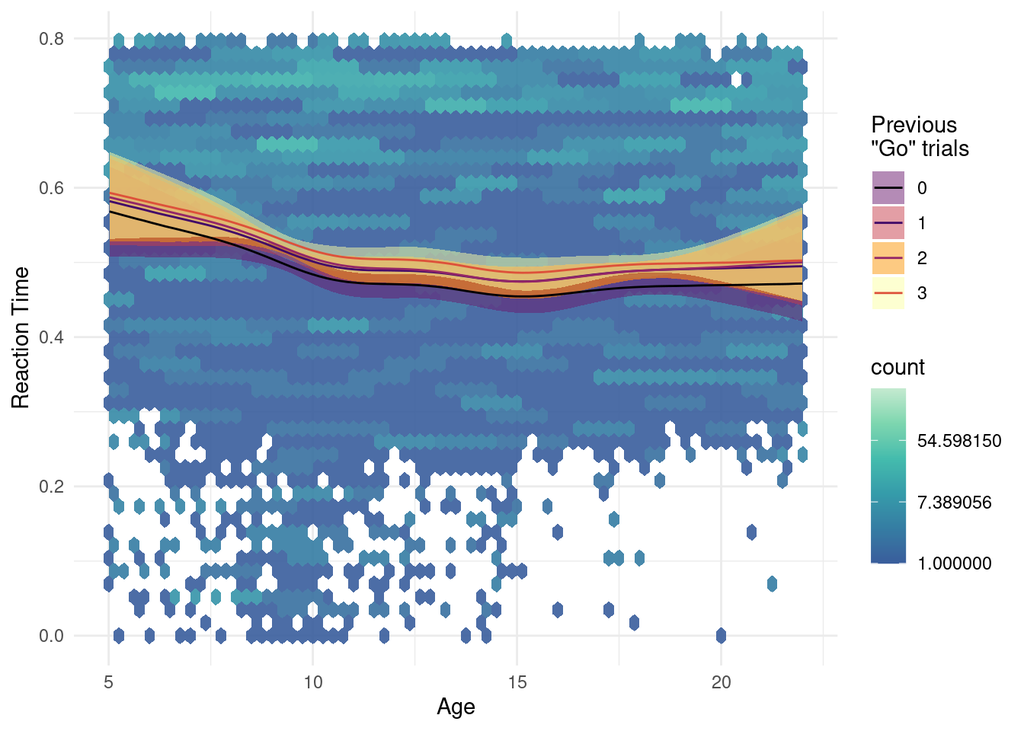

```r
rt_age_prepotofac_fit <- read_fit_models('rt_age_prepotofac')

print(plot_cond_eff(fit = rt_age_prepotofac_fit, xvar = 'age', xname = 'Age', yname = 'Reaction Time',
                    conditions = data.frame(exact_prepotency_ofactor = 0:3),
                    condition_title = 'Previous\n"Go" trials', mean_center_y = FALSE,
                    method = 'posterior_epred', hex = TRUE, hex_log = TRUE,
                    hex_args = list(alpha = .9, binwidth = c(.25, .02))))
```

```r
#ggsave(filename = 'rt_age_prepotofac.png', width = 11, height = 6.95, units = 'in', dpi = 300)
```

**Posterior predictive check**

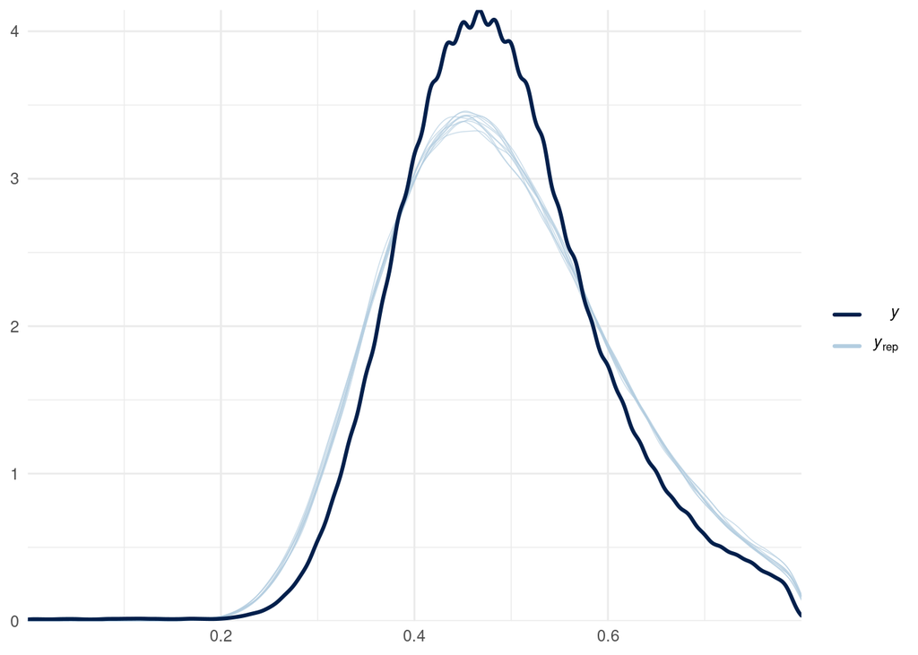

```r
pp_check(rt_age_prepotofac_fit) + theme_minimal()
```

**Model summary**

```r
summary(rt_age_prepotofac_fit)
```

```
 Family: lognormal
  Links: mu = identity; sigma = identity
Formula: RT.shape | trunc(ub = 0.8) ~ time + exact_prepotency_ofactor + s(age) + s(age, by = exact_prepotency_ofactor) + (1 + time | sID_factor:runN_factor) + (1 + time + exact_prepotency_ofactor | sID_factor)
   Data: structure(list(RT.shape = c(0.492612123489998, 0.6 (Number of observations: 143253)
  Draws: 4 chains, each with iter = 2500; warmup = 1500; thin = 1;
         total post-warmup draws = 4000

Smooth Terms:
                                     Estimate Est.Error l-95% CI u-95% CI Rhat
sds(sage_1)                              0.39      0.21     0.13     0.90 1.01
sds(sageexact_prepotency_ofactor1_1)     0.02      0.02     0.00     0.08 1.00
sds(sageexact_prepotency_ofactor2_1)     0.04      0.04     0.00     0.15 1.01
sds(sageexact_prepotency_ofactor3_1)     0.05      0.04     0.01     0.15 1.00
                                     Bulk_ESS Tail_ESS
sds(sage_1)                               289      787
sds(sageexact_prepotency_ofactor1_1)     1596     2018
sds(sageexact_prepotency_ofactor2_1)      827     1678
sds(sageexact_prepotency_ofactor3_1)     1758     1758

Group-Level Effects:
~sID_factor (Number of levels: 1236)
                                                           Estimate Est.Error
sd(Intercept)                                                  0.10      0.00
sd(time)                                                       0.02      0.00
sd(exact_prepotency_ofactor.L)                                 0.04      0.00
sd(exact_prepotency_ofactor.Q)                                 0.03      0.00
sd(exact_prepotency_ofactor.C)                                 0.02      0.00
cor(Intercept,time)                                            0.85      0.08
cor(Intercept,exact_prepotency_ofactor.L)                     -0.34      0.06
cor(time,exact_prepotency_ofactor.L)                          -0.42      0.15
cor(Intercept,exact_prepotency_ofactor.Q)                     -0.05      0.08
cor(time,exact_prepotency_ofactor.Q)                          -0.18      0.17
cor(exact_prepotency_ofactor.L,exact_prepotency_ofactor.Q)    -0.46      0.11
cor(Intercept,exact_prepotency_ofactor.C)                      0.24      0.10
cor(time,exact_prepotency_ofactor.C)                           0.44      0.16
cor(exact_prepotency_ofactor.L,exact_prepotency_ofactor.C)    -0.15      0.13
cor(exact_prepotency_ofactor.Q,exact_prepotency_ofactor.C)    -0.71      0.10
                                                           l-95% CI u-95% CI
sd(Intercept)                                                  0.10     0.11
sd(time)                                                       0.01     0.02
```

[output cut: 66 more lines]

```
exact_prepotency_ofactor.L           4689     3490
exact_prepotency_ofactor.Q           5788     3335
exact_prepotency_ofactor.C           5638     3364
sage_1                               1134     1989
sage:exact_prepotency_ofactor1_1     2217     1569
sage:exact_prepotency_ofactor2_1     1139     1324
sage:exact_prepotency_ofactor3_1     2478     2599

Family Specific Parameters:
      Estimate Est.Error l-95% CI u-95% CI Rhat Bulk_ESS Tail_ESS
sigma     0.22      0.00     0.22     0.22 1.00     7088     2967

Draws were sampled using sample(hmc). For each parameter, Bulk_ESS
and Tail_ESS are effective sample size measures, and Rhat is the potential
scale reduction factor on split chains (at convergence, Rhat = 1).
```

# How does change in reaction time across sequential Go-trials predict accuracy?

**Plot effect**

The plots here show the correlations between the random effects from two models. The *prepotency* random effect is the random slope of the effect of the number of previous Go trials on the reaction time—that is, how much does a previous Go trial increase or decrease the RT, for each person. The *accuracy* random effect is the random intercept from the model of accuracy predicted by age, meaning it’s each person’s average accuracy after accounting for age (that is, a person’s deviation from the age trend). The top density in the plot represents the posterior probability distribution for the size of the correlation between these two random effects, with shading up to the 95% credible interval, and lines out to the 99.9% credible interval.

A positive correlation between these random effects would indicate that people who have a greater tendency to speed up with each Go (smaller RTs) also tend to have lower accuracy.

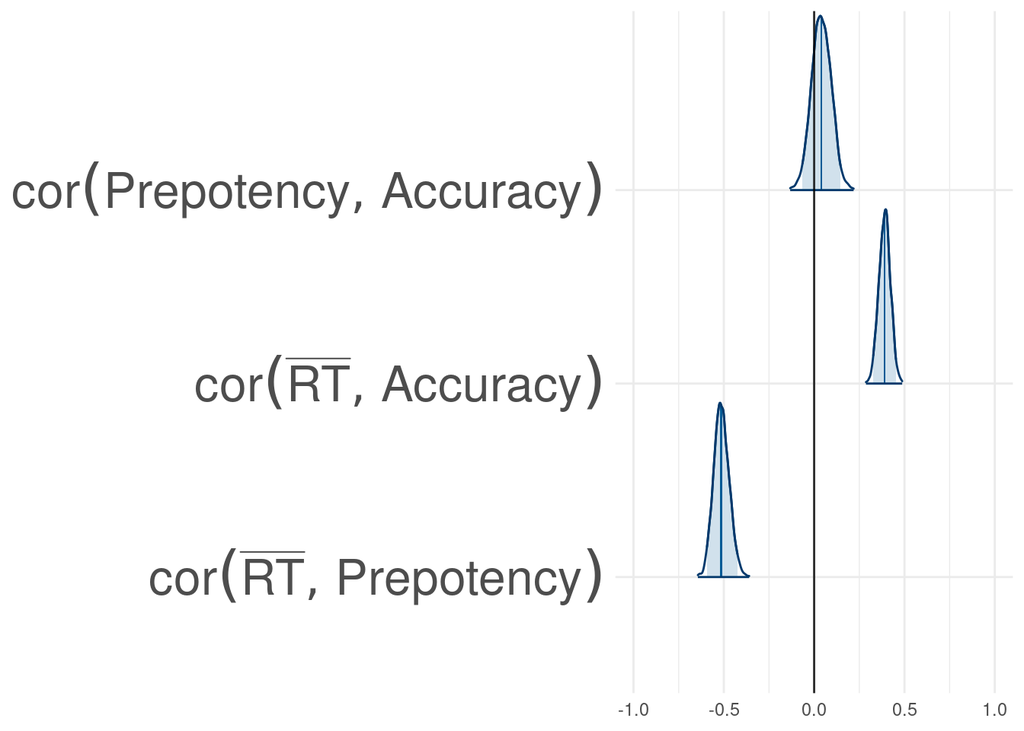

```r
accprepot_fit <- read_fit_models('accprepot')

p <- brms::mcmc_plot(accprepot_fit,
                variable = '^cor_sID_factor__.*',
                regex = TRUE, type = 'areas', area_method = 'equal height',
                prob = 1-.05, prob_outer = 1-.001)
p + scale_y_discrete(labels = c(expression(cor(bar(textstyle("RT")), textstyle("Prepotency"))),
                                expression(cor(bar(textstyle("RT")), textstyle("Accuracy"))),
                                expression(cor(textstyle("Prepotency"), textstyle("Accuracy"))))) +
  coord_cartesian(x = c(-1, 1)) +
  geom_vline(xintercept = 0, alpha = .8) +
  theme_minimal() +
  theme(axis.text.y = element_text(size = 24))
```

```r
#ggsave(filename = 'accprepot_fit.png', width = 11, height = 6.95, units = 'in', dpi = 300)
```

We see no credibly positive or negative association between prepotency effect and accuracy. The second two posterior densities represent correlations that weren’t of focal interest. The first is between average reaction time and average accuracy (after accounting for age), while the final is between average reaction time and the degree of prepotency effect (again, after accounting for age). The former suggests that people with higher average reaction times are more accurate (i.e., taking one’s time improves accuracy). In light of the average prepotency effect being *positive* (people strategically slow down with every go trial), the latter negative correlation suggests that people with higher reaction times show a reduced prepotency effect; that is, less strategic participants are slower.

**Posterior predictive check**

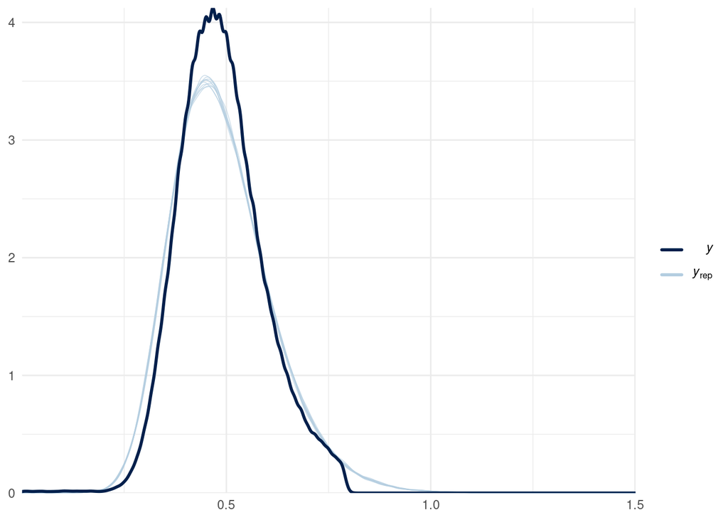

```r
pp_check(accprepot_fit, resp = 'RTshape') + theme_minimal()
```

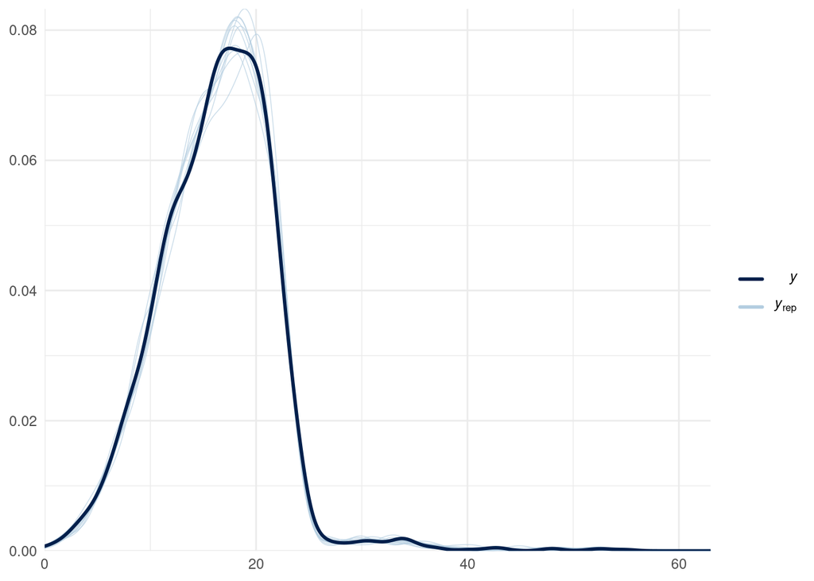

```r
pp_check(accprepot_fit, resp = 'corRejecttotal') + theme_minimal()
```

**Model summary**

```r
summary(accprepot_fit)
```

```
 Family: MV(shifted_lognormal, binomial)
  Links: mu = identity; sigma = identity; ndt = identity
         mu = logit
Formula: RT.shape | subset(subsetRT) ~ t2(age, exact_prepotency, k = c(10, 3)) + (1 + exact_prepotency | ID1 | sID_factor) + (1 + exact_prepotency | sID_factor:runN_factor)
         corReject.total | trials(nogo.total) + subset(subsetACC) ~ 1 + s(age_ACC, k = 10) + (1 | ID1 | sID_factor)
   Data: structure(list(subset = c("RT", "RT", "RT", "RT",  (Number of observations: 145695)
  Draws: 4 chains, each with iter = 2500; warmup = 1500; thin = 1;
         total post-warmup draws = 4000

Smooth Terms:
                                     Estimate Est.Error l-95% CI u-95% CI Rhat
sds(RTshape_t2ageexact_prepotency_1)     0.03      0.03     0.00     0.12 1.00
sds(RTshape_t2ageexact_prepotency_2)     0.66      0.69     0.15     2.61 1.00
sds(RTshape_t2ageexact_prepotency_3)     0.23      0.08     0.12     0.41 1.00
sds(corRejecttotal_sage_ACC_1)           1.24      0.54     0.52     2.59 1.00
                                     Bulk_ESS Tail_ESS
sds(RTshape_t2ageexact_prepotency_1)     1474     2053
sds(RTshape_t2ageexact_prepotency_2)     1450     1846
sds(RTshape_t2ageexact_prepotency_3)      934     1446
sds(corRejecttotal_sage_ACC_1)           1127     1796

Group-Level Effects:
~sID_factor (Number of levels: 1180)
                                                       Estimate Est.Error
sd(RTshape_Intercept)                                      0.11      0.00
sd(RTshape_exact_prepotency)                               0.02      0.00
sd(corRejecttotal_Intercept)                               0.67      0.02
cor(RTshape_Intercept,RTshape_exact_prepotency)           -0.51      0.04
cor(RTshape_Intercept,corRejecttotal_Intercept)            0.39      0.03
cor(RTshape_exact_prepotency,corRejecttotal_Intercept)     0.04      0.05
                                                       l-95% CI u-95% CI Rhat
sd(RTshape_Intercept)                                      0.10     0.11 1.00
sd(RTshape_exact_prepotency)                               0.02     0.02 1.00
sd(corRejecttotal_Intercept)                               0.64     0.71 1.00
cor(RTshape_Intercept,RTshape_exact_prepotency)           -0.59    -0.42 1.00
cor(RTshape_Intercept,corRejecttotal_Intercept)            0.33     0.45 1.00
cor(RTshape_exact_prepotency,corRejecttotal_Intercept)    -0.06     0.15 1.01
                                                       Bulk_ESS Tail_ESS
sd(RTshape_Intercept)                                       993     1919
sd(RTshape_exact_prepotency)                               1242     2240
```

[output cut: 24 more lines]

```
RTshape_Intercept                    663     1462
corRejecttotal_Intercept            1298     1771
RTshape_t2ageexact_prepotency_1     2791     3185
RTshape_t2ageexact_prepotency_2     1021     1928
RTshape_t2ageexact_prepotency_3     2926     3234
corRejecttotal_sage_ACC_1           1780     2233

Family Specific Parameters:
              Estimate Est.Error l-95% CI u-95% CI Rhat Bulk_ESS Tail_ESS
sigma_RTshape     0.22      0.00     0.22     0.22 1.00     7764     3047
ndt_RTshape       0.00      0.00     0.00     0.00 1.00     4554     2072

Draws were sampled using sample(hmc). For each parameter, Bulk_ESS
and Tail_ESS are effective sample size measures, and Rhat is the potential
scale reduction factor on split chains (at convergence, Rhat = 1).
```

# How does accuracy vary with previous reward history, conditional on age?

**Plot accuracy x age x reward history effect**

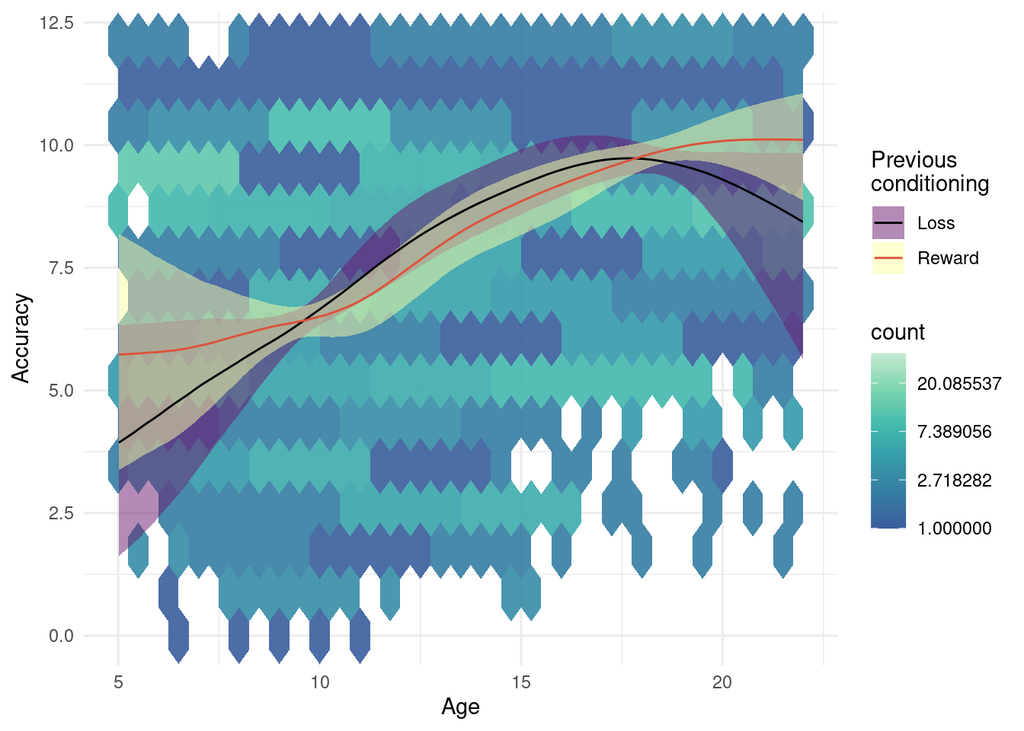

```r
acc_prevcond_fit <- read_fit_models('acc_prevcond')
acc_prevcond_null_fit <- read_fit_models('acc_prevcond_null')

print(plot_cond_eff(fit = acc_prevcond_fit, xvar = 'age_ACC', xname = 'Age', yname = 'Accuracy',
                    conditions = data.frame(nogoCondition = c('prevLossNogo', 'prevRewNogo'),
                                            nogo.total = c(12,12)),
                    condition_title = 'Previous\nconditioning',
                    breaks = c('prevLossNogo', 'prevRewNogo'),
                    labels = c('Loss', 'Reward'),
                    hex = TRUE, hex_log = TRUE,
                    hex_args = list(alpha = .9, binwidth = c(.5, 1))))
```

```r
#ggsave(filename = 'acc_prevcond_fit.png', width = 11, height = 6.95, units = 'in', dpi = 300)
```

**Plot best fitting model**

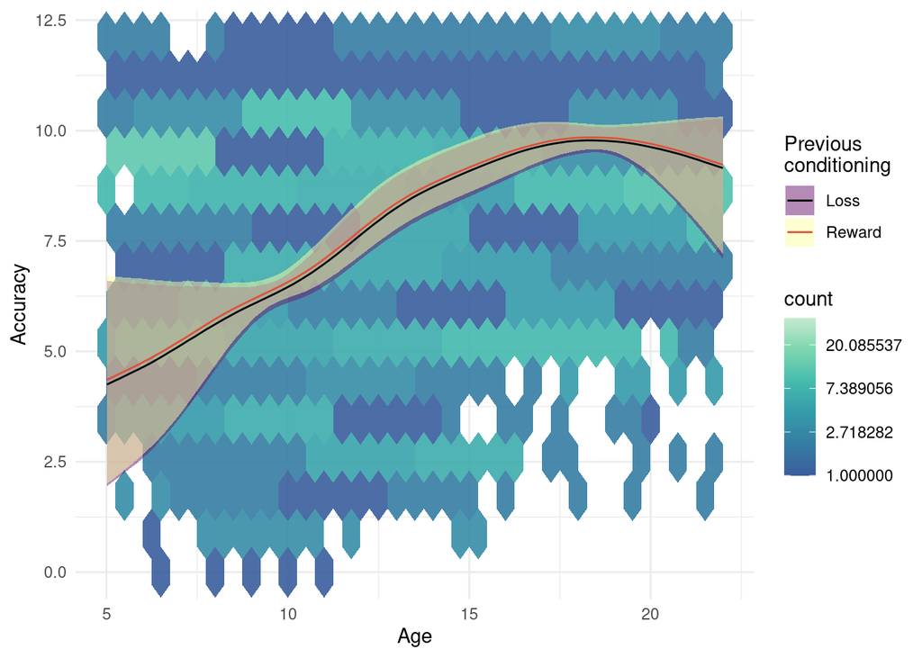

```r
print(plot_cond_eff(fit = acc_prevcond_null_fit, xvar = 'age_ACC', xname = 'Age', yname = 'Accuracy',
                    conditions = data.frame(nogoCondition = c('prevLossNogo', 'prevRewNogo'),
                                            nogo.total = c(12,12)),
                    condition_title = 'Previous\nconditioning',
                    breaks = c('prevLossNogo', 'prevRewNogo'),
                    labels = c('Loss', 'Reward'),
                    hex = TRUE, hex_log = TRUE,
                    hex_args = list(alpha = .9, binwidth = c(.5, 1))))
```

```r
#ggsave(filename = 'acc_prevcond_null_fit.png', width = 11, height = 6.95, units = 'in', dpi = 300)
```

**LOO Compare**

```r
loo_compare(loo(acc_prevcond_fit), loo(acc_prevcond_null_fit))
```

```
                      elpd_diff se_diff
acc_prevcond_null_fit   0.0       0.0
acc_prevcond_fit      -23.5      49.2
```

**Model summary**

```r
summary(acc_prevcond_fit)
```

```
 Family: binomial
  Links: mu = logit
Formula: corReject.total | trials(nogo.total) ~ 1 + nogoCondition + s(age_ACC, by = nogoCondition, k = 10) + (1 | sID_factor)
   Data: structure(list(sID_factor = structure(c(1L, 1L, 1L (Number of observations: 4542)
  Draws: 4 chains, each with iter = 2500; warmup = 1500; thin = 1;
         total post-warmup draws = 4000

Smooth Terms:
                                         Estimate Est.Error l-95% CI u-95% CI
sds(sage_ACCnogoConditionprevRewNogo_1)      1.37      0.58     0.61     2.79
sds(sage_ACCnogoConditionprevLossNogo_1)     1.46      0.61     0.64     2.91
                                         Rhat Bulk_ESS Tail_ESS
sds(sage_ACCnogoConditionprevRewNogo_1)  1.00     1111     1849
sds(sage_ACCnogoConditionprevLossNogo_1) 1.00      998     1291

Group-Level Effects:
~sID_factor (Number of levels: 1234)
              Estimate Est.Error l-95% CI u-95% CI Rhat Bulk_ESS Tail_ESS
sd(Intercept)     0.67      0.02     0.63     0.71 1.00     1166     1968

Population-Level Effects:
                                     Estimate Est.Error l-95% CI u-95% CI Rhat
Intercept                                0.79      0.02     0.74     0.83 1.00
nogoConditionprevLossNogo               -0.05      0.02    -0.09    -0.01 1.00
sage_ACC:nogoConditionprevRewNogo_1      0.03      0.85    -1.66     1.67 1.00
sage_ACC:nogoConditionprevLossNogo_1     0.21      0.84    -1.48     1.88 1.00
                                     Bulk_ESS Tail_ESS
Intercept                                1222     2131
nogoConditionprevLossNogo                6268     2611
sage_ACC:nogoConditionprevRewNogo_1      3636     2589
sage_ACC:nogoConditionprevLossNogo_1     3832     3188

Draws were sampled using sample(hmc). For each parameter, Bulk_ESS
and Tail_ESS are effective sample size measures, and Rhat is the potential
scale reduction factor on split chains (at convergence, Rhat = 1).
```

**Best fitting model summary**

```r
summary(acc_prevcond_null_fit)
```

```
 Family: binomial
  Links: mu = logit
Formula: corReject.total | trials(nogo.total) ~ 1 + nogoCondition + s(age_ACC, k = 10) + (1 | sID_factor)
   Data: structure(list(sID_factor = structure(c(1L, 1L, 1L (Number of observations: 4542)
  Draws: 4 chains, each with iter = 2500; warmup = 1500; thin = 1;
         total post-warmup draws = 4000

Smooth Terms:
                Estimate Est.Error l-95% CI u-95% CI Rhat Bulk_ESS Tail_ESS
sds(sage_ACC_1)     1.46      0.61     0.65     2.91 1.00      919     1802

Group-Level Effects:
~sID_factor (Number of levels: 1234)
              Estimate Est.Error l-95% CI u-95% CI Rhat Bulk_ESS Tail_ESS
sd(Intercept)     0.67      0.02     0.63     0.70 1.00     1293     2032

Population-Level Effects:
                          Estimate Est.Error l-95% CI u-95% CI Rhat Bulk_ESS
Intercept                     0.78      0.02     0.73     0.82 1.00     1453
nogoConditionprevLossNogo    -0.04      0.02    -0.08    -0.00 1.00     6063
sage_ACC_1                    0.08      0.87    -1.66     1.79 1.00     3616
                          Tail_ESS
Intercept                     2345
nogoConditionprevLossNogo     2946
sage_ACC_1                    2980

Draws were sampled using sample(hmc). For each parameter, Bulk_ESS
and Tail_ESS are effective sample size measures, and Rhat is the potential
scale reduction factor on split chains (at convergence, Rhat = 1).
```